# ARodriguez_ProjectFullCodeNB_EasyVisa

# **Model Comparison and Final Model Selection**

```python
# training performance comparison

models_train_comp_df = pd.concat(
    [
        adb_train.T,
        gbm_train.T,
        gbm2_train.T,
    ],
    axis=1,
)
models_train_comp_df.columns = [
    "AdaBoost trained with Oversampled data",
    "Gradient boosting trained with Oversampled data",
    "Gradient boosting trained with Undersampled data",
]
print("Training performance comparison:")
models_train_comp_df
```

```
Training performance comparison:
```

|  | AdaBoost trained with Oversampled data | Gradient boosting trained with Oversampled data | Gradient boosting trained with Undersampled data |
| --- | --- | --- | --- |
| Accuracy | 0.647 | 1.000 | 0.704 |
| Recall | 0.931 | 1.000 | 0.743 |
| Precision | 0.594 | 1.000 | 0.689 |
| F1 | 0.725 | 1.000 | 0.715 |

```python
# Validation performance comparison

models_train_comp_df = pd.concat(
    [adb_val.T, gbm_val.T, gbm2_val.T], axis=1,
)
models_train_comp_df.columns = [
    "AdaBoost trained with Oversampled data",
    "Gradient boosting trained with Oversampled data",
    "Gradient boosting trained with Undersampled data"
]
print("Validation performance comparison:")
models_train_comp_df
```

```
Validation performance comparison:
```

|  | AdaBoost trained with Oversampled data | Gradient boosting trained with Oversampled data | Gradient boosting trained with Undersampled data |
| --- | --- | --- | --- |
| Accuracy | 0.716 | 0.665 | 0.717 |
| Recall | 0.934 | 0.743 | 0.735 |
| Precision | 0.722 | 0.753 | 0.823 |
| F1 | 0.815 | 0.748 | 0.776 |

- AdaBoost trained with oversampled data remained the most stable in terms of recall so I consider this the best model.

```python
# Let's check the performance on test set
ada_test = model_performance_classification_sklearn(tuned_adb, X_test, y_test)
ada_test
```

|  | Accuracy | Recall | Precision | F1 |
| --- | --- | --- | --- | --- |
| 0 | 0.708 | 0.930 | 0.717 | 0.810 |

- AdaBoost returned the test set with a 93% recall which is consistent with recalls achieved with training and validation sets.
- This indicates that this model generalizes well.

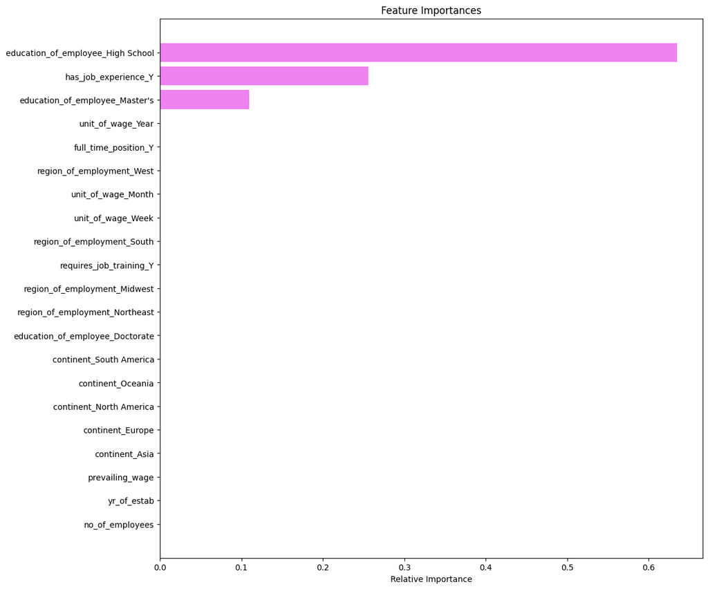

```python
# Compute feature importances
feature_names = X_train.columns
importances = tuned_adb.feature_importances_
indices = np.argsort(importances)

plt.figure(figsize=(12, 12))
plt.title("Feature Importances")
plt.barh(range(len(indices)), importances[indices], color="violet", align="center")
plt.yticks(range(len(indices)), [feature_names[i] for i in indices])
plt.xlabel("Relative Importance")
plt.show()
```

- Feature importances indicate that High School education, Master's level education and previous job experience are major determining factors in the Visa approval process.

# **Actionable Insights and Recommendations**

- Education level plays a significant role in whether an applicant's Visa is Certified or Denied. Those will only a High School Education were significantly less likely to be approved, while those holding a Master's or above had the highest rates of approval.
- Prior job experience is also a key factor separating Certified versus Denied applications. Individuals demonstrating work history significantly increase their chances of Visa approval.
- EasyVisa's profile could prioritize applications combining higher education and previous work experience, while flagging applicants that are only High School educated or have no work experience. This will help streamline the process by focusing first on candidates that are most likely to be approved.

```python
!pip install nbconvert
```

```python
from google.colab import drive
drive.mount('/content/drive')

from google.colab import files

notebook_name = "/content/drive/MyDrive/ColabNotebooks/AARodriguez_ProjectFullCodeNB_EasyVisa.ipynbRodriguez_Project_SLC_DSBA_INNHotels_FullCode.ipynb"
html_output_name = notebook_name.replace('.ipynb', '.html')

get_ipython().system(f'jupyter nbconvert --to html "{notebook_name}"')
files.download(html_output_name)
```